# Anàlisi de mesures repetides

Antonio Miñarro (aminarro@ub.edu)

02 gener, 2026

# 1 Les mesures repetides

- Un disseny recurrent en la metodologia experimental es aquell en que els subjectes són analitzats repetidament al llarg del temps o en que tots els nivells d’un factor són mesurats sobre les mateixes unitats experimentals. Aquests experiments s’anomenen experiments amb **mesures repetides o longitudinals**.
- El cas típic seria la generalització del test t de Student per dades aparellades al cas en que tinguem tres o mes mesures temporals.
- Un altre exemple seria mesurar sobre un mateix individu una característica determinada sobre diferents parts del cos: ull dret i esquerra, etc.
- L’individu és una característica que acostuma a aportar una gran part de la variabilitat sobre la mesura. La unitat experimental que es mesura diverses vegades (l’individu) **deixa de ser considerat una rèplica** i es converteix en una font de variabilitat (factor) del model. Generalment no estem interessats mai en les unitats experimentals i les considerem un **bloc**.
- El problema que tindrem és que poden vulnerar-se algunes premises sobre la dependencia entre les observacions.

## 1.1 Exemple 1: Cinètica d’un producte

- En un determinat estudi es desitja comparar la evolució d’un producte al llarg del temps.
- S’aplica el producte a 12 voluntaris amb la mateixa patologia.
- Es mesura el producte al llarg del temps i es prenen 3 mesures (**mesures repetides**) sobre els individus a temps 1, 2 i 3.
- Les dades obtingudes són les següents

```r
repe1<-read.table('../dades/MR_Exemple1.csv',header=T,sep=';',dec=',')
repe1$indiv<-as.factor(repe1$indiv)
repe1$temps<-as.factor(repe1$temp)
head(repe1)
```

| indiv | temps | mesura |
| --- | --- | --- |
| 1 | 1 | 39.4 |
| 2 | 1 | 33.5 |
| 3 | 1 | 27.1 |
| 4 | 1 | 30.9 |
| 5 | 1 | 32.2 |
| 6 | 1 | 26.6 |

```r
tail(repe1)
```

|  | indiv | temps | mesura |
| --- | --- | --- | --- |
| 31 | 7 | 3 | 36.4 |
| 32 | 8 | 3 | 55.3 |
| 33 | 9 | 3 | 46.4 |
| 34 | 10 | 3 | 38.3 |
| 35 | 11 | 3 | 37.3 |
| 36 | 12 | 3 | 52.6 |

```r
summary(repe1)
```

```
##      indiv    temps      mesura
##  1      : 3   1:12   Min.   :24.40
##  2      : 3   2:12   1st Qu.:36.23
##  3      : 3   3:12   Median :40.60
##  4      : 3          Mean   :42.99
##  5      : 3          3rd Qu.:52.75
##  6      : 3          Max.   :68.60
##  (Other):18
```

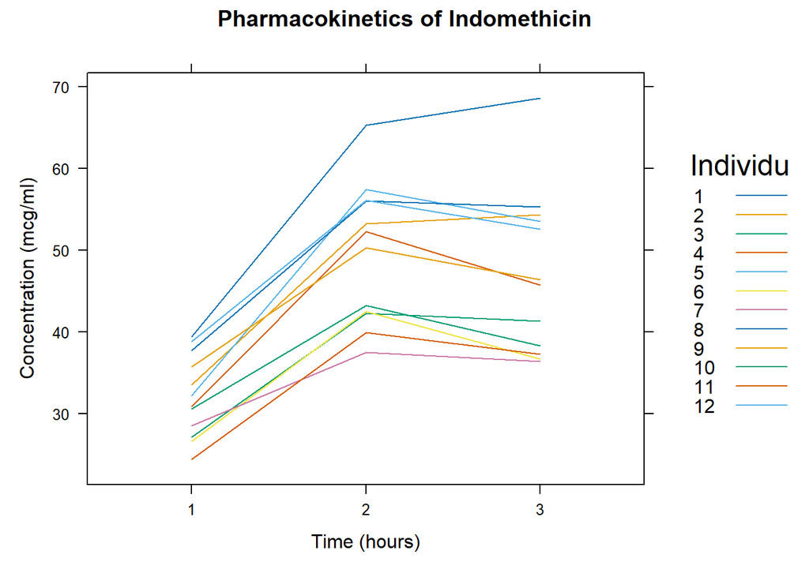

```r
library(lattice)
myplot1 <-xyplot(mesura~temps,data=repe1,groups=factor(indiv,levels=c(1:12)),type='l',
       auto.key=list(title='Individu',space='right',points=F,lines=T),
       main = "Pharmacokinetics of Indomethicin",
       ylab = "Concentration (mcg/ml)",
       xlab = "Time (hours)")
print(myplot1)
```

## 1.2 Model experimental

- El temps és considerat un **factor fix amb tants nivells com mesures** fem a cada individu.
- Els individus són un **factor aleatori** sobre el que no tenim especial interès en contrastar el seu efecte però han d’estar en el model perquè introdueixen una variabilitat. Són un **bloc**.
- Tenim una observació sobre cada individu i temps. **Una rèplica per condició experimental**.
- En aquest exemple el nostre interés es centra en determinar si existeix una variació temporal. **Significació del factor temps**.
- El model és formalment equivalent al model d’un factor fix amb un bloc aleatori i una rèplica per condició experimental (model RCBD).

## 1.3 Mesures repetides simples (1WS)

El model és el següent:

$$Y_{ij} = \mu +\pi_i + \beta_j + e_{ij}$$

amb $i=1,...,n$, $j=1,...,b$.

on

- $Y_{ij}$ és l’observació de l’individu $i$ en el nivell $j$ de la mesura repetida.
- $\mu$ és una mitjana general
- $\beta_j$ és un paràmetre del model que mesura l’efecte del nivell $j$ de la mesura repetida.
- $\pi_i$ és una variable aleatoria que mesure l’efecte de l’individu.
- $e_{ij}$ és l’error aleatori corresponent a l’observació $i,j$.

En aquest cas $\sum_{i=1}^b \beta_j = 0$; $\pi_i \sim N(0,\sigma_\pi)$; $e_{ij} \sim N(0,\sigma)$ i les variables aleatòries $\pi_i$ i $e_{ij}$ són independents.

Es un model per tant **idèntic al model de blocs aleatoritzats (RCBD)**, on l’individu fa el paper de bloc aleatori.

## 1.4 Correlació de les dades en un model de mesures repetides simples

- Hem vist anteriorment que en dissenys de dos factors on un factor és fix i l’altre aleatori les observacions dintre del mateix nivell del factor aleatori estan correlacionades.
- En el cas particular d’un model RCBD o el model de mesures repetides considerat com un RCBD on l’individu fa el paper de bloc aleatori

$$Cov(Y_{ij},Y_{i'j'}) = \left\{
\begin{array}{ll}
\sigma^2_\pi & \mbox{ si } i = i' , j \ne j' \\
0 & \mbox{ si } i \ne i'\end{array} \right.$$

En el cas de la mateixa observació la covariància és equivalent a la variància i per tant $Cov(Y_{ij},Y_{ij}) = \sigma_\pi^2 + \sigma^2$.

Observacions d’individus diferents estan incorrelacionades i les covariàncies i per tant les correlacions entre qualsevol parell d’observacions d’un mateix individu (dintre d’un mateix bloc) han de ser totes iguals. Es a dir la correlació ha de ser igual entre qualsevol parell d’observacions d’un mateix individu. Esquematicament la matriu de covariàncies entre les observacions d’un individu $(\Sigma_i)$, ha de ser:

$$\Sigma_i = \left( \begin{array}{cccc}
\sigma^2+\sigma^2_\pi & \sigma^2_\pi & \cdots & \sigma^2_\pi
\\
\sigma^2_\pi & \sigma^2+\sigma^2_\pi & \cdots & \sigma^2_\pi
\\
\vdots & \vdots & \ddots & \vdots \\
\sigma^2_\pi & \sigma^2_\pi & \cdots &\sigma^2+\sigma^2_\pi
\\ \end{array}
\right)$$

Per tant l’estructura de correlacions entre les mesures d’un mateix individu és la següent:

$$\left( \begin{array}{cccc}
1 & \rho & \cdots & \rho \\
\rho & 1 & \cdots & \rho \\
\vdots & \vdots & \ddots & \vdots \\
\rho & \rho & \cdots &1 \\ \end{array}
\right)$$

Veiem esquemàticament les diferències entre un model RCBD i un model de mesures repetides.

[figure not shown]

La condició de igualtat de correlacions entre qualsevol parell de tractaments s’esquematitza

[figure not shown]

Aquesta condició s’anomena **simetria composta**. És una condició sufficient però és molt restrictiva i no és necessària. Una condició menys restrictiva és l’**esfericitat** o **condició de Huynh-Feldt (H-F)** que implica que les variàncies entre les diferències entre valors de la variable resposta són iguals entre tractaments.

El problema és que a la pràctica és molt freqüent que no es verifiqui la condició H-F i per tant no podem aplicar directament el model com en el cas RCBD.

Si no tenim esfericitat tornem a tenir **descontrolada la probabilitat d’error de tipus I**.

En aquest cas presentearem dues solucions:

- Introduir unes **correccions** a la taula ANOVA. Solució clàssica.
- La solució més actual de modelar amb un nou tipus de models que permeten incloure diferents estructures de correlacions. **Models lineals mixtos (MLM)** o **Linear Mixed Models (LMM)** en anglès.

## 1.5 Contrastos i premisses del model de mesures repetides simple

- L’únic contrast que ens interessa és

$$H_0: \beta_1 = \beta_2 = \cdots =
\beta_b = 0$$
$$H_1: \beta_j
\ne \beta_{j'} \mbox{ per algun } j \ne j' \,\,\, ( \mbox{
equivalentment }H_1: \exists \beta_j \ne 0)$$

Usualment no plantegem el contrast sobre el factor individu.

- Les premisses són:

– Com sempre, independència i distribució $N(0,\sigma)$.

– La condició d’esfericitat H-F es contrasta amb el **test d’esfericitat de Mauchly**

## 1.6 Correccions en cas de no esfericitat

- El grau en el que la matriu de covariàncies s’allunya de l’esfericitat es mesura per un paràmetre anomenat **epsilon** $\epsilon$. Com més s’allunya epsilon del valor 1 és pitjor la violació de l’esfericitat. La correcció consisteix en multiplicar els graus de llibertat del numerador i denominador de la F pel paràmetre $\epsilon$.
- **Només s’han de corregir les F dels factors que són mesures repetides** (temps per exemple).
- Hi han dues versions per estimar el paràmetre $\epsilon$

– Correcció de **Greenhouse-Geisser**

– Correcció de **Huynh-Feldt**

La primera és una mica més conservadora però és la recomanada per molts autors. Altres autors recomanen la de **Huynh-Feldt** per mostres petites, justament pel fet de ser més liberal.

Una alternativa si no es disposa de les correccions és multiplicar els graus de llibertat pel valor mínim de $\epsilon$, que és 1/(b-1) sent conscient que és la correcció més conservadora. Si el factor és significatiu amb la correcció conservadora llavors acceptem $H_1$, si el factor és significatiu sense correcció i no ho és amb la correcció conservadora llavors hem d’aplicar una de las dues correccions més acurades.

## 1.7 Resolució amb R (package ez)

### 1.7.1 Resolució amb un model RCBD sense verificar esfericitat

```r
head(repe1)
```

| indiv | temps | mesura |
| --- | --- | --- |
| 1 | 1 | 39.4 |
| 2 | 1 | 33.5 |
| 3 | 1 | 27.1 |
| 4 | 1 | 30.9 |
| 5 | 1 | 32.2 |
| 6 | 1 | 26.6 |

```r
repe1.aov<-aov(mesura~temps+indiv,repe1)
anova(repe1.aov)
```

|  | Df | Sum Sq | Mean Sq | F value | Pr(>F) |
| --- | --- | --- | --- | --- | --- |
| temps | 2 | 2166.3756 | 1083.18778 | 90.05264 | 0e+00 |
| indiv | 11 | 1892.0589 | 172.00535 | 14.29996 | 1e-07 |
| Residuals | 22 | 264.6244 | 12.02838 | NA | NA |

**No podem estar segurs de la validesa de la taula**

### 1.7.2 Resolució amb el package **ez** que fa la verificació del test de Mauchly i les correccions

```r
library(ez)
ezANOVA(data=repe1,within=.(temps),wid=.(indiv),dv=.(mesura),type=3,detailed = T)
```

```
## $ANOVA
##        Effect DFn DFd       SSn       SSd         F            p p<.05
## 1 (Intercept)   1  11 66546.801 1892.0589 386.88796 6.390053e-10     *
## 2       temps   2  22  2166.376  264.6244  90.05264 2.542699e-11     *
##         ges
## 1 0.9686088
## 2 0.5011210
##
## $`Mauchly's Test for Sphericity`
##   Effect         W          p p<.05
## 2  temps 0.4433135 0.01712201     *
##
## $`Sphericity Corrections`
##   Effect       GGe        p[GG] p[GG]<.05       HFe        p[HF] p[HF]<.05
## 2  temps 0.6423901 5.662497e-08         * 0.6905331 1.998401e-08         *
```

La **hipòtesi nul·la del test de Mauchly és l’esfericitat**, rebutjar-la vol dir que no hi ha esfericitat i és necessari aplicar les correccions als p-valors.

Si el factor que representa la mesura repetida surt significatiu es poden fer comparacions múltiples, però no hi ha una tècnica específica. Poden fer-ser comparacions per parelles amb un test per dades aparellades i aplicar una técnica d’ajust als p-valors, per exemple Bonferroni o també algunes alternatives menys conservadores (veure la funció **p.adjust** de R).

## 1.8 Obtenció dels residus i verificació de la premissa de normalitat

El package *ez* **no** proporciona els residus del model. Si volem obtenir els residus i verificar la normalitat podem utilitzar un nou package **afex** que disposa d’una funció **aov_ez** que emula el resultat de la funció **ez** del package del mateix nom i que ens proporciona els residus.

```r
library(afex)
repe1.afex<-aov_ez(data=repe1,within='temps',id='indiv',dv='mesura',type=3)
summary(repe1.afex)
```

```
##
## Univariate Type III Repeated-Measures ANOVA Assuming Sphericity
##
##             Sum Sq num Df Error SS den Df F value    Pr(>F)
## (Intercept)  66547      1  1892.06     11 386.888 6.390e-10 ***
## temps         2166      2   264.62     22  90.053 2.543e-11 ***
## ---
## Signif. codes:  0 '***' 0.001 '**' 0.01 '*' 0.05 '.' 0.1 ' ' 1
##
##
## Mauchly Tests for Sphericity
##
##       Test statistic  p-value
## temps        0.44331 0.017122
##
##
## Greenhouse-Geisser and Huynh-Feldt Corrections
##  for Departure from Sphericity
##
##        GG eps Pr(>F[GG])
## temps 0.64239  5.662e-08 ***
## ---
## Signif. codes:  0 '***' 0.001 '**' 0.01 '*' 0.05 '.' 0.1 ' ' 1
##
##          HF eps   Pr(>F[HF])
## temps 0.6905331 1.998401e-08
```

Podem obtenir els residus i els valors predits amb les instruccions

```r
repe1.afex$lm$residuals
repe1.afex$lm$fitted
```

i fer el gràfic amb la instrucció

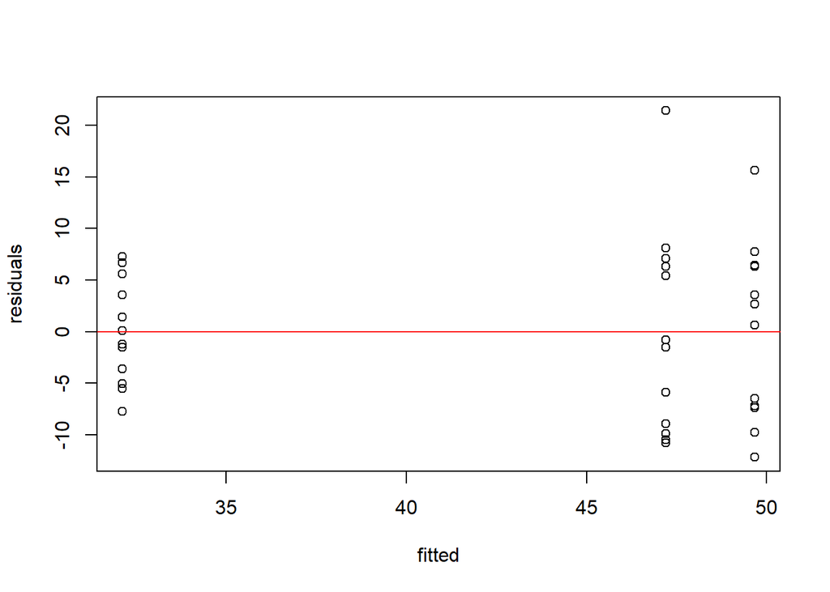

```r
plot(repe1.afex$lm$fitted.values,repe1.afex$lm$residuals,xlab='fitted',ylab='residuals')
abline(h=0,col='red')
```

La verificació de la normalitat pot fer-se amb la funció **check_normality** del package **performance**.

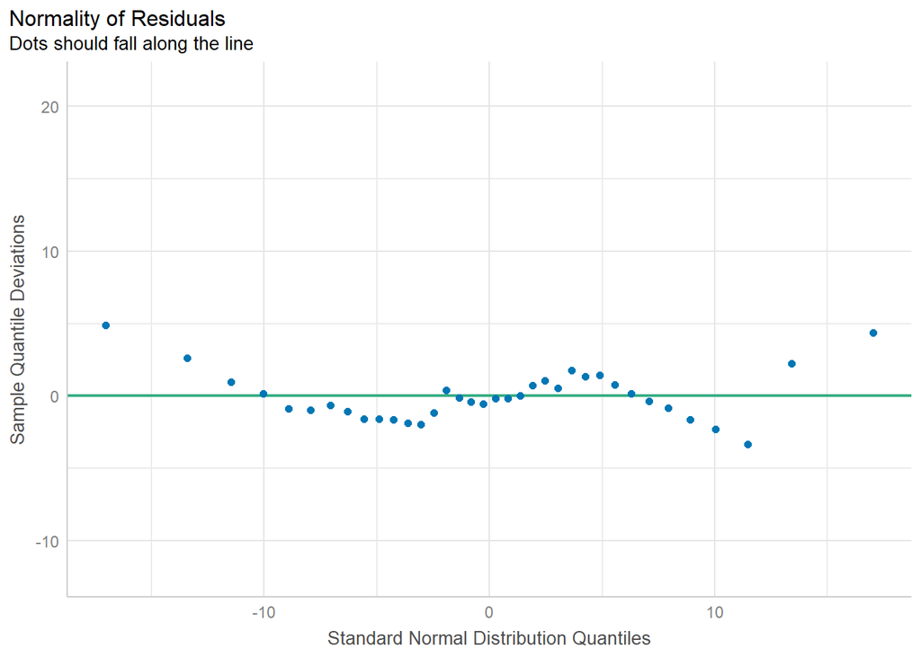

```r
library(performance)
check.nor<-check_normality(repe1.afex)
plot(check.nor)
```

## 1.9 Resolució amb models lineals mixtos (MLM)

Els models lineals mixtos (Linear Mixed Models = LMM) són una generalització dels models lineals (LM) per a situacions en que tenim factors fixos i aleatoris i que permeten superar algunes de les restriccions que fins ara teníem:

- Permeten treballar amb mesures repetides amb **diferents estructures de correlacions, sense les restriccions del model clàssic que imposa simetria composada**.

$$R =\left( \begin{array}{cccc}
1 & \rho & \cdots & \rho \\
\rho & 1 & \cdots & \rho \\
\vdots & \vdots & \ddots & \vdots \\
\rho & \rho & \cdots &1 \\ \end{array}
\right)$$

- Permeten introduir correlacions entre factors aleatoris i entre residus, a diferència de la incorrelació que requereix el LM.
- Permeten modelar la heterocedasticitat

Els LMM van ser introduïts per Fisher fa quasi 100 anys, però només en les darreres decades s’ha estès la seva utilització en l’anàlisi de mesures repetides.

- Actualment és la tècnica preferida per aquest tipus de dades, desplaçant l’ús de les correccions G-G i H-F

## 1.10 Estructures de correlacions entre mesures d’un mateix individu

De les moltes possibilitats de modelar que tenen els LMM ens centrarem només en les estructures de correlacions que poden definir-se per a les mesures repetides.

Les més utilitzades són les següents:

- Recordem l’estructura anomenada **simetria composada** característica dels models RCBD

$$\Sigma_i = \left( \begin{array}{cccc}
\sigma^2+\sigma^2_\pi & \sigma^2_\pi & \cdots & \sigma^2_\pi
\\
\sigma^2_\pi & \sigma^2+\sigma^2_\pi & \cdots & \sigma^2_\pi
\\
\vdots & \vdots & \ddots & \vdots \\
\sigma^2_\pi & \sigma^2_\pi & \cdots &\sigma^2+\sigma^2_\pi
\\ \end{array}
\right)$$

i la matriu de correlacions entre mesures és

$$R =\left( \begin{array}{cccc}
1 & \rho & \cdots & \rho \\
\rho & 1 & \cdots & \rho \\
\vdots & \vdots & \ddots & \vdots \\
\rho & \rho & \cdots &1 \\ \end{array}
\right)$$

- Estructura **auto-regressiva d’ordre 1 AR(1)**

Les covariàncies i correlacions disminueixen exponencialment amb la distància en el temps.

$$R = \left( \begin{array}{ccccc}
1 &\rho & \rho^2 & \cdots & \rho^{b-1} \\
\rho & 1 & \rho & \cdots & \rho^{b-2} \\
\rho^2 & \rho & 1 & \cdots & \rho^{b-3} \\
\vdots & \vdots & \vdots & \ddots & \vdots \\
\rho^{b-1} & \rho^{b-2} & \rho^{b-3} & \cdots &1 \\
\end{array}
\right)$$

- Toeplitz

Similar a l’AR (1), on totes les mesures adjacents tenen la mateixa correlació, i en general totes les mesures separades una mateixa distància tenen la mateixa correlació. Tècnicament, l’AR (1) és un cas especial del Toeplitz.

$$R = \left( \begin{array}{ccccc}
1 & \rho_1 & \rho_2 & \cdots & \rho_{b-1} \\
\rho_1 & 1 & \rho_1 & \cdots & \rho_{b-2} \\
\rho_2 & \rho_1 & 1 & \cdots & \rho_{b-3} \\
\vdots & \vdots & \ddots & \vdots \\
\rho_{b-1} & \rho_{b-2} & \rho_{b-3} & \cdots & 1 \\ \\
\end{array}
\right)$$

- Sense estructura

Es la más general però la quantitat de paràmetres a estimar fa que sigui més complicada de tractar numèricament.

$$R = \left( \begin{array}{ccccc}
1 & \rho_{12} & \rho_{13} & \cdots & \rho_{1b} \\
\rho_{12} & 1 & \rho_{23} & \cdots & \rho_{2b} \\
\vdots & \vdots & \ddots & \vdots \\
\rho_{1b} & \rho_{2b} & \rho_{3b} & \cdots & 1 \\ \\
\end{array}
\right)$$

Fixem-nos que el número de paràmetres en les diferents estructures és:

- Simetria composada: 2
- AR(1): 2
- Toeplitz: b
- Sense estructura: 1+b(b-1)/2

## 1.11 LMM en R amb el package **nlme**

Farem servir la funció **lme** del package *nlme*.

La forma d’introduir un model té dos components:

- La part fixa s’introdueix de la forma habitual
  - Exemple 1: mesura ~ temps
  - Exemple 2: weight ~ group * week
- La part aleatòria s’especifica a part amb el paràmetre **random**
  - Exemple 1: random=~1|indiv
  - Exemple 2: random=~1|id

L’estructura de correlacions s’introdueix amb el paràmetre **correlation**

- *corAR1*: auto-regressiva d’ordre 1 AR(1)
- *corCompSymm*: simetria composada, característica dels models RCBD
- *corSymm*: matriu general de correlacions sense estructura definida

**Nota:** Toeplitz no està implimentat com a tal a **nlme**.

## 1.12 Resolució de l’exemple 1 amb **nlme**

### 1.12.1 Resolució amb simetria composada

```r
library(nlme)
lme.fit1<-lme(mesura~temps,random=~1|indiv,correlation=corCompSymm(),data=repe1)
summary(lme.fit1)
```

```
## Linear mixed-effects model fit by REML
##   Data: repe1
##        AIC      BIC    logLik
##   224.4474 233.4264 -106.2237
##
## Random effects:
##  Formula: ~1 | indiv
##         (Intercept) Residual
## StdDev:    7.302442 3.468196
##
## Correlation Structure: Compound symmetry
##  Formula: ~1 | indiv
##  Parameter estimate(s):
## Rho
##   0
## Fixed effects:  mesura ~ temps
##                Value Std.Error DF  t-value p-value
## (Intercept) 32.11667  2.333703 22 13.76211       0
## temps2      17.55000  1.415885 22 12.39507       0
## temps3      15.08333  1.415885 22 10.65294       0
##  Correlation:
##        (Intr) temps2
## temps2 -0.303
## temps3 -0.303  0.500
##
## Standardized Within-Group Residuals:
##         Min          Q1         Med          Q3         Max
## -1.86144700 -0.44121660 -0.06110589  0.54616137  2.20887269
##
## Number of Observations: 36
## Number of Groups: 12
```

```r
anova(lme.fit1)
```

|  | numDF | denDF | F-value | p-value |
| --- | --- | --- | --- | --- |
| (Intercept) | 1 | 22 | 386.88797 | 0 |
| temps | 2 | 22 | 90.05264 | 0 |

Compareu el resultat amb el que hem obtingut amb la funció **ez**

També podem demanar que ens ensenyi la matriu de covariàncies o de correlacions entre els temps.

```r
(covmat1<-getVarCov(lme.fit1,type='marginal'))
```

```
## indiv 1
## Marginal variance covariance matrix
##        1      2      3
## 1 65.354 53.326 53.326
## 2 53.326 65.354 53.326
## 3 53.326 53.326 65.354
##   Standard Deviations: 8.0842 8.0842 8.0842
```

```r
cov2cor(covmat1[[1]])
```

```
##           1         2         3
## 1 1.0000000 0.8159504 0.8159504
## 2 0.8159504 1.0000000 0.8159504
## 3 0.8159504 0.8159504 1.0000000
```

### 1.12.2 Resolució amb model auto-regressiu

```r
lme.fit2<-lme(mesura~temps,random=~1|indiv,correlation=corAR1(),data=repe1)
summary(lme.fit2)
```

```
## Linear mixed-effects model fit by REML
##   Data: repe1
##        AIC      BIC    logLik
##   218.5602 227.5392 -103.2801
##
## Random effects:
##  Formula: ~1 | indiv
##         (Intercept) Residual
## StdDev: 0.001728971 7.935395
##
## Correlation Structure: AR(1)
##  Formula: ~1 | indiv
##  Parameter estimate(s):
##       Phi
## 0.8708748
## Fixed effects:  mesura ~ temps
##                Value Std.Error DF  t-value p-value
## (Intercept) 32.11667  2.290751 22 14.02015       0
## temps2      17.55000  1.164122 22 15.07574       0
## temps3      15.08333  1.592285 22  9.47276       0
##  Correlation:
##        (Intr) temps2
## temps2 -0.254
## temps3 -0.348  0.684
##
## Standardized Within-Group Residuals:
##         Min          Q1         Med          Q3         Max
## -1.53321493 -0.83696732 -0.04515635  0.79496144  2.69677804
##
## Number of Observations: 36
## Number of Groups: 12
```

```r
anova(lme.fit2)
```

|  | numDF | denDF | F-value | p-value |
| --- | --- | --- | --- | --- |
| (Intercept) | 1 | 22 | 351.6112 | 0 |
| temps | 2 | 22 | 114.2979 | 0 |

Matriu de covariàncies entre els temps.

```r
(covmat2<-getVarCov(lme.fit2,type='marginal'))
```

```
## indiv 1
## Marginal variance covariance matrix
##        1      2      3
## 1 62.970 54.839 47.758
## 2 54.839 62.970 54.839
## 3 47.758 54.839 62.970
##   Standard Deviations: 7.9354 7.9354 7.9354
```

```r
cov2cor(covmat2[[1]])
```

```
##           1         2         3
## 1 1.0000000 0.8708748 0.7584229
## 2 0.8708748 1.0000000 0.8708748
## 3 0.7584229 0.8708748 1.0000000
```

### 1.12.3 Resolució amb model sense estructura

```r
lme.fit3<-lme(mesura~temps,random=~1|indiv,correlation=corSymm(),data=repe1)
summary(lme.fit3)
```

```
## Linear mixed-effects model fit by REML
##   Data: repe1
##        AIC      BIC    logLik
##   218.5233 230.4954 -101.2616
##
## Random effects:
##  Formula: ~1 | indiv
##         (Intercept) Residual
## StdDev:    7.069757 3.498312
##
## Correlation Structure: General
##  Formula: ~1 | indiv
##  Parameter estimate(s):
##  Correlation:
##   1      2
## 2  0.081
## 3 -0.561  0.628
## Fixed effects:  mesura ~ temps
##                Value Std.Error DF   t-value p-value
## (Intercept) 32.11667  2.277053 22 14.104488       0
## temps2      17.55000  1.368874 22 12.820757       0
## temps3      15.08333  1.784415 22  8.452817       0
##  Correlation:
##        (Intr) temps2
## temps2 -0.301
## temps3 -0.392  0.880
##
## Standardized Within-Group Residuals:
##        Min         Q1        Med         Q3        Max
## -1.9546650 -0.4858829 -0.0760596  0.4768065  2.0806149
##
## Number of Observations: 36
## Number of Groups: 12
```

```r
anova(lme.fit3)
```

|  | numDF | denDF | F-value | p-value |
| --- | --- | --- | --- | --- |
| (Intercept) | 1 | 22 | 319.46671 | 0 |
| temps | 2 | 22 | 99.95899 | 0 |

Matriu de covariàncies entre els temps.

```r
(covmat3<-getVarCov(lme.fit3,type='marginal'))
```

```
## indiv 1
## Marginal variance covariance matrix
##        1      2      3
## 1 62.220 50.977 43.115
## 2 50.977 62.220 57.669
## 3 43.115 57.669 62.220
##   Standard Deviations: 7.8879 7.8879 7.8879
```

```r
cov2cor(covmat3[[1]])
```

```
##           1         2         3
## 1 1.0000000 0.8193031 0.6929455
## 2 0.8193031 1.0000000 0.9268634
## 3 0.6929455 0.9268634 1.0000000
```

## 1.13 Selecció de la millor estructura de covariàncies

- L’elecció de l’estructura de covariàncies és important i té implicacions en els resultats dels tests.
- Son moltes les consideracions que es poden tenir en compte: número de paràmetres, interpretació aplicada de l’estructura, resultats de l’ajust, experiments anteriors, etc.
- Si no tenim una idea clara podem recòrrer als criteris d’informació (IC).
- Els criteris d’informació són una mesura de la qualitat d’un model estadístic i tenen en compte tant la bondat de l’ajust com el número de paràmetres que fan servir. Alguns dels més utilitzats són:
  - AIC (Akaike Information criterion)
  - BIC (Bayesian Information criterion)
  - Log-Likelihood

Tant per a l’AIC com per al BIC el criteri és que el millor és el que té un **menor valor**. Per al Log-Likelihood el criteri és el contrari, és millor el més gran.

- Les diferències entre AIC i BIC s’accentuen quan més complex és el model. No hi ha acord actualment sobre quin utilitzar
- BIC tendeix a seleccionar models més simples en estar més penalitzat que l’AIC pel nombre de paràmetres del model
- Seleccionar un model massa simple tendeix a augmentar el risc de l’error de tipus I, per tant, millor utilitzar AIC quan controlar aquest error resulta prioritari, en canvi, si la preocupació principal és la potència dels tests, sembla preferible BIC

## 1.14 Exemple 2

Es vol analitzar l’efecte en el creixement dels conills porquins d’afegir a la dieta un suplement de vitamina E. Tres grups d’animals han rebut respectivament una dosi zero, baixa i alta de vitamina E i s’ha registrat el pes de cada animal a les setmanes 1, 2, 3, 4, 5 i 6 després d’iniciar el tractament. La variable resposta és el pes en grams. Podem concloure que existeix un patró diferent al llarg del temps entre els diferents grups de tractament?

[figure not shown]

```r
repe2<-read.table('../dades/MR_Exemple2.csv',header=T,sep=';',dec=',')
repe2$id<-as.factor(repe2$id)
repe2$group<-as.factor(repe2$group)
repe2$week<-as.factor(repe2$week)
head(repe2,10)
```

| id | group | weight | week |
| --- | --- | --- | --- |
| 1 | 1 | 455 | 1 |
| 1 | 1 | 460 | 2 |
| 1 | 1 | 510 | 3 |
| 1 | 1 | 504 | 4 |
| 1 | 1 | 436 | 5 |
| 1 | 1 | 466 | 6 |
| 2 | 1 | 467 | 1 |
| 2 | 1 | 565 | 2 |
| 2 | 1 | 610 | 3 |
| 2 | 1 | 596 | 4 |

```r
tail(repe2,10)
```

|  | id | group | weight | week |
| --- | --- | --- | --- | --- |
| 81 | 14 | 3 | 580 | 3 |
| 82 | 14 | 3 | 601 | 4 |
| 83 | 14 | 3 | 633 | 5 |
| 84 | 14 | 3 | 649 | 6 |
| 85 | 15 | 3 | 472 | 1 |
| 86 | 15 | 3 | 498 | 2 |
| 87 | 15 | 3 | 540 | 3 |
| 88 | 15 | 3 | 524 | 4 |
| 89 | 15 | 3 | 532 | 5 |
| 90 | 15 | 3 | 583 | 6 |

## 1.15 Mesures repetides amb un factor entre grups (1 WS + 1 BS)

- Una variant molt freqüent és que els individus estiguin classificats en diferents grups de tractament i es facin diverses mesures sobre ells.
- Llavors tenim un model amb un factor entre individus (BS) i un factor dintre dels individus (WS) (mesura repetida).
- En el nostre exemple (3 dietes i 6 mesures setmanals de 15 conills porquins)

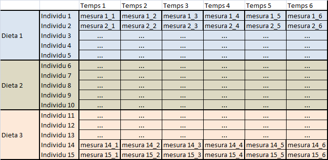

- Els individus estan niats al factor grup.
- Les mesures repetides estan creuades respecte tant els individus com al grup.
- La resta de fons de variabilitat són no controlades
- El model estructural és el següent

$$Y_{ijk} = \mu + \alpha_i + \pi_{j(i)} +
\beta_k + (\alpha \beta)_{ik}+ e_{ijk}$$

amb $i=1,...,a$, $j=1,...,n$ , $k=1,...,b$.

- Els contrastos rellevants són:

$$H_0: \alpha_1 = \alpha_2 = \cdots =
\alpha_a = 0$$
$$H_1: \exists
\alpha_i \ne 0)$$

$$H_0: \beta_1 = \beta_2 = \cdots =
\beta_b = 0$$
$$H_1: \exists \beta_k
\ne 0$$

$$H_0: (\alpha \beta)_{ik} = 0 \,\,\,
\forall i,k$$
$$H_1: \exists (\alpha
\beta)_{ik} \ne 0$$

Usualment no plantegem el contrast sobre el factor individu, fa el paper de bloc.

### 1.15.1 Taula ANOVA amb un disseny balancejat

| Font de variació | Suma de quadrats | Graus de llibertat | Quadrats mitjans | Estadístic F |
| --- | --- | --- | --- | --- |
| Tractament (fix) | $SS_A$ | $a-1$ | $MS_A = \frac{SS_A}{a-1}$ | $F = \frac{MS_A}{MS_{I(A)}}$ |
| Mesura repetida (fix) | $SS_B$ | $b-1$ | $MS_B = \frac{SS_B}{b-1}$ | $F = \frac{MS_B}{MS_E}$ |
| Individu (aleat) | $SS_{I(A)}$ | $a(n-1)$ | $MS_{I(A)} = \frac{SS_{I(A)}}{a(n-1)}$ | $F = \frac{MS_I(A)}{MS_E}$ |
| Interacció AB | $SS_{AB}$ | $(a-1)(b-1)$ | $MS_{AB} = \frac{SS_{AB}}{(a-1)(b-1)}$ | $F = \frac{MS_{AB}}{MS_E}$ |
| Error | $SS_E$ | $a(b-1)(n-1)$ | $MS_E = \frac{SS_E}{a(b-1)(n-1)}$ |  |
| Total | $SS_T$ | $N-1$ |  |  |

## 1.16 Exemple 2, resolució amb R:

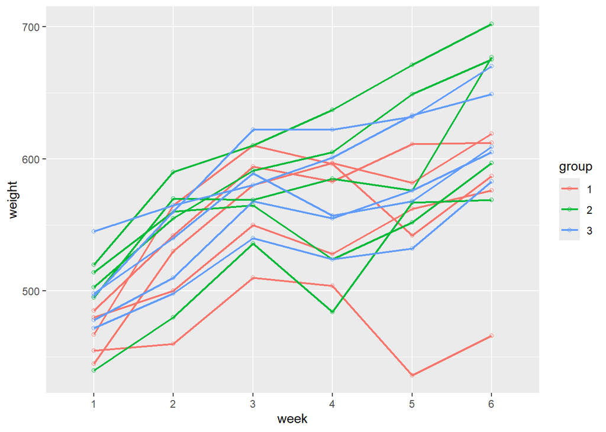

```r
library(ggplot2)

ggplot(repe2, aes(x=week,y=weight,colour=group)) + geom_line(aes(group=id),linewidth=0.8) + geom_point(shape=1)
```

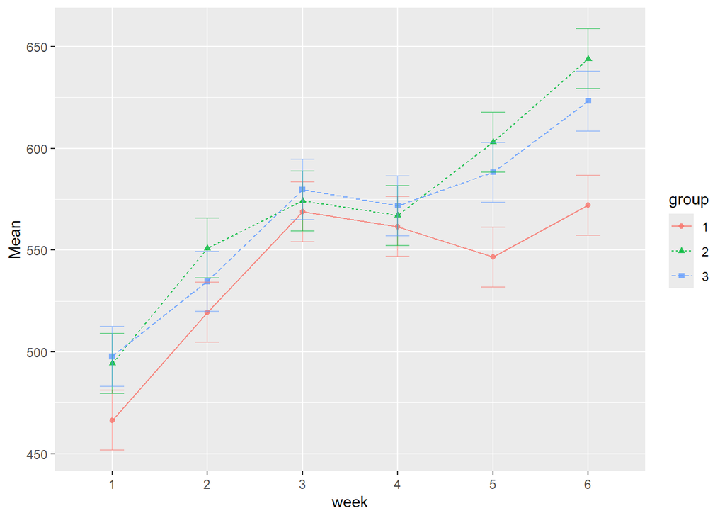

```r
ezPlot(data=repe2,between=.(group),within=.(week),wid=.(id),dv=.(weight),x=.(week),split=.(group))
```

```r
ezANOVA(data=repe2,between=.(group),within=.(week),wid=.(id),dv=.(weight),type=3,detailed = T)
```

```
## $ANOVA
##        Effect DFn DFd          SSn      SSd           F            p p<.05
## 1 (Intercept)   1  12 28133352.900 105434.2 3201.999302 6.120979e-16     *
## 2       group   2  12    18548.067 105434.2    1.055525 3.782088e-01
## 3        week   5  60   142554.500  32552.6   52.550457 1.169141e-20     *
## 4  group:week  10  60     9762.733  32552.6    1.799438 8.014404e-02
##          ges
## 1 0.99511920
## 2 0.11849160
## 3 0.50814087
## 4 0.06607624
##
## $`Mauchly's Test for Sphericity`
##       Effect          W          p p<.05
## 3       week 0.05448352 0.01091271     *
## 4 group:week 0.05448352 0.01091271     *
##
## $`Sphericity Corrections`
##       Effect       GGe        p[GG] p[GG]<.05       HFe        p[HF] p[HF]<.05
## 3       week 0.4855731 4.257871e-11         * 0.6176731 1.461416e-13         *
## 4 group:week 0.4855731 1.457120e-01           0.6176731 1.242842e-01
```

- La condició d’esfericitat es verifica sobre els factors que corresponen a les mesures repetides i les seves interaccions. **No respecte els factors BS**.

La resolució també pot fer-se amb el package **afex**

```r
library(afex)
repe2.afex<-aov_ez(data=repe2,between='group',within='week',id='id',dv='weight',type=3)
summary(repe2.afex)
```

```
##
## Univariate Type III Repeated-Measures ANOVA Assuming Sphericity
##
##               Sum Sq num Df Error SS den Df   F value    Pr(>F)
## (Intercept) 28133353      1   105434     12 3201.9993 6.121e-16 ***
## group          18548      2   105434     12    1.0555   0.37821
## week          142554      5    32553     60   52.5505 < 2.2e-16 ***
## group:week      9763     10    32553     60    1.7994   0.08014 .
## ---
## Signif. codes:  0 '***' 0.001 '**' 0.01 '*' 0.05 '.' 0.1 ' ' 1
##
##
## Mauchly Tests for Sphericity
##
##            Test statistic  p-value
## week             0.054484 0.010913
## group:week       0.054484 0.010913
##
##
## Greenhouse-Geisser and Huynh-Feldt Corrections
##  for Departure from Sphericity
##
##             GG eps Pr(>F[GG])
## week       0.48557  4.258e-11 ***
## group:week 0.48557     0.1457
## ---
## Signif. codes:  0 '***' 0.001 '**' 0.01 '*' 0.05 '.' 0.1 ' ' 1
##
##               HF eps   Pr(>F[HF])
## week       0.6176731 1.461416e-13
## group:week 0.6176731 1.242842e-01
```

que ens permet la verificació de normalitat i homogeneïtat de variàncies.

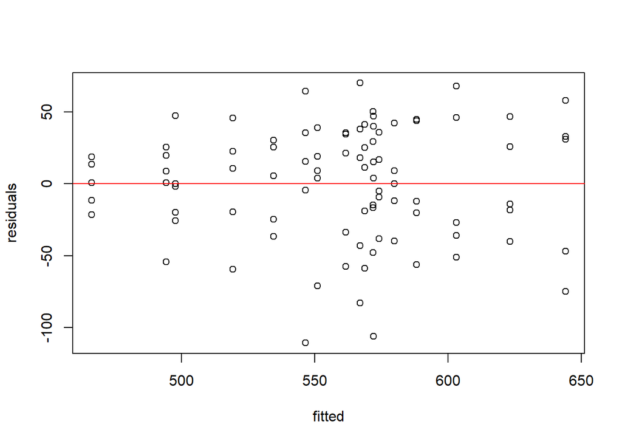

```r
plot(repe2.afex$lm$fitted.values,repe2.afex$lm$residuals,xlab='fitted',ylab='residuals')
abline(h=0,col='red')
```

```
## For confidence bands, please install `qqplotr`.
```

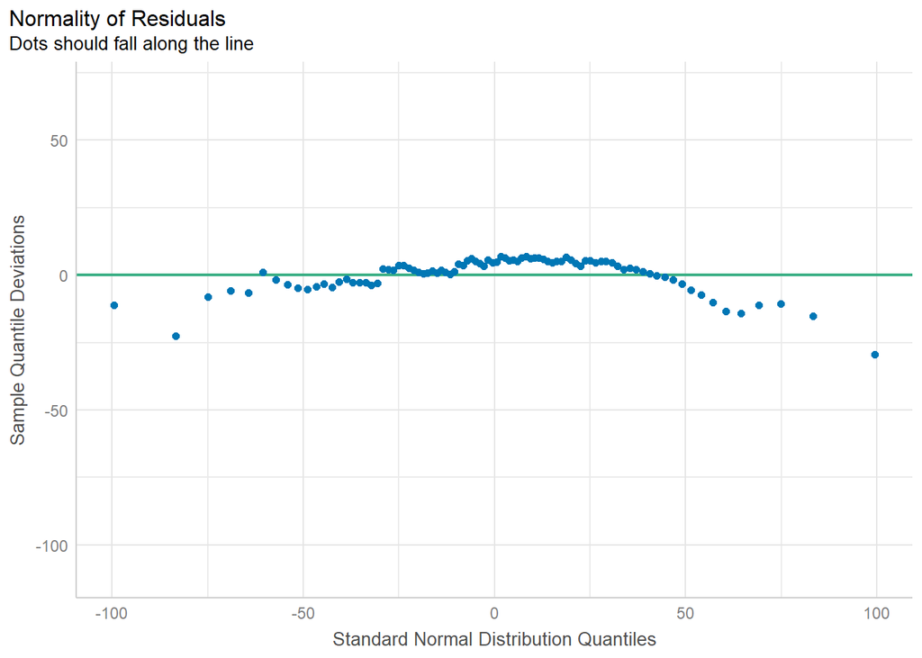

```r
check.nor<-check_normality(repe2.afex)
plot(check.nor)
```

En aquest cas també podem verificar la homogeneïtat de variàncies amb el package **performance** que ens fa el test de Levene.

```r
check_homogeneity(repe2.afex)
```

```
## OK: There is not clear evidence for different variances across groups (Levene's Test, p = 0.882).
```

## 1.17 Resolució de l’exemple 2 amb **nlme**

### 1.17.1 Resolució amb simetria composada

```r
lme2.fit1<-lme(weight~group*week,random=~1|id,correlation=corCompSymm(),data=repe2)
aux<-summary(lme2.fit1)
c(AIC=aux$AIC,BIC=aux$BIC,logLik=aux$logLik)
```

```
##       AIC       BIC    logLik
##  762.0443  809.8543 -360.0222
```

```r
anova(lme2.fit1)
```

|  | numDF | denDF | F-value | p-value |
| --- | --- | --- | --- | --- |
| (Intercept) | 1 | 60 | 3201.999302 | 0.0000000 |
| group | 2 | 12 | 1.055525 | 0.3782088 |
| week | 5 | 60 | 52.550457 | 0.0000000 |
| group:week | 10 | 60 | 1.799438 | 0.0801440 |

Matriu de covariàncies entre els temps.

```r
(covmat1<-getVarCov(lme2.fit1,type='marginal'))
```

```
## id 1
## Marginal variance covariance matrix
##        1      2      3      4      5      6
## 1 1916.5 1373.9 1373.9 1373.9 1373.9 1373.9
## 2 1373.9 1916.5 1373.9 1373.9 1373.9 1373.9
## 3 1373.9 1373.9 1916.5 1373.9 1373.9 1373.9
## 4 1373.9 1373.9 1373.9 1916.5 1373.9 1373.9
## 5 1373.9 1373.9 1373.9 1373.9 1916.5 1373.9
## 6 1373.9 1373.9 1373.9 1373.9 1373.9 1916.5
##   Standard Deviations: 43.778 43.778 43.778 43.778 43.778 43.778
```

```r
cov2cor(covmat1[[1]])
```

```
##           1         2         3         4         5         6
## 1 1.0000000 0.7169068 0.7169068 0.7169068 0.7169068 0.7169068
## 2 0.7169068 1.0000000 0.7169068 0.7169068 0.7169068 0.7169068
## 3 0.7169068 0.7169068 1.0000000 0.7169068 0.7169068 0.7169068
## 4 0.7169068 0.7169068 0.7169068 1.0000000 0.7169068 0.7169068
## 5 0.7169068 0.7169068 0.7169068 0.7169068 1.0000000 0.7169068
## 6 0.7169068 0.7169068 0.7169068 0.7169068 0.7169068 1.0000000
```

Compareu el resultat amb el que hem obtingut amb la funció **ez**

### 1.17.2 Resolució amb model auto-regressiu

```r
lme2.fit2<-lme(weight~group*week,random=~1|id,correlation=corAR1(),data=repe2)
aux<-summary(lme2.fit2)
c(AIC=aux$AIC,BIC=aux$BIC,logLik=aux$logLik)
```

```
##       AIC       BIC    logLik
##  750.1329  797.9428 -354.0664
```

```r
anova(lme2.fit2)
```

|  | numDF | denDF | F-value | p-value |
| --- | --- | --- | --- | --- |
| (Intercept) | 1 | 60 | 3423.169277 | 0.0000000 |
| group | 2 | 12 | 1.647735 | 0.2331903 |
| week | 5 | 60 | 34.449726 | 0.0000000 |
| group:week | 10 | 60 | 1.553461 | 0.1432434 |

Matriu de covariàncies entre els temps.

```r
(covmat1<-getVarCov(lme2.fit2,type='marginal'))
```

```
## id 1
## Marginal variance covariance matrix
##         1      2      3      4      5       6
## 1 1852.50 1513.6 1292.0 1147.2 1052.5  990.65
## 2 1513.60 1852.5 1513.6 1292.0 1147.2 1052.50
## 3 1292.00 1513.6 1852.5 1513.6 1292.0 1147.20
## 4 1147.20 1292.0 1513.6 1852.5 1513.6 1292.00
## 5 1052.50 1147.2 1292.0 1513.6 1852.5 1513.60
## 6  990.65 1052.5 1147.2 1292.0 1513.6 1852.50
##   Standard Deviations: 43.04 43.04 43.04 43.04 43.04 43.04
```

```r
cov2cor(covmat1[[1]])
```

```
##           1         2         3         4         5         6
## 1 1.0000000 0.8170401 0.6974462 0.6192724 0.5681731 0.5347715
## 2 0.8170401 1.0000000 0.8170401 0.6974462 0.6192724 0.5681731
## 3 0.6974462 0.8170401 1.0000000 0.8170401 0.6974462 0.6192724
## 4 0.6192724 0.6974462 0.8170401 1.0000000 0.8170401 0.6974462
## 5 0.5681731 0.6192724 0.6974462 0.8170401 1.0000000 0.8170401
## 6 0.5347715 0.5681731 0.6192724 0.6974462 0.8170401 1.0000000
```

### 1.17.3 Resolució amb model sense estructura

```r
lme2.fit3<-lme(weight~group*week,random=~1|id,correlation=corSymm(),data=repe2)
aux<-summary(lme2.fit3)
c(AIC=aux$AIC,BIC=aux$BIC,logLik=aux$logLik)
```

```
##       AIC       BIC    logLik
##  745.9797  825.6630 -337.9898
```

```r
anova(lme2.fit3)
```

|  | numDF | denDF | F-value | p-value |
| --- | --- | --- | --- | --- |
| (Intercept) | 1 | 60 | 21105.894281 | 0.0000000 |
| group | 2 | 12 | 10.302480 | 0.0024853 |
| week | 5 | 60 | 38.478162 | 0.0000000 |
| group:week | 10 | 60 | 3.742741 | 0.0006057 |

Matriu de covariàncies entre els temps.

```r
(covmat3<-getVarCov(lme2.fit3,type='marginal'))
```

```
## id 1
## Marginal variance covariance matrix
##         1       2       3       4       5      6
## 1 1588.50  732.31 -181.77  397.38  381.80  332.1
## 2  732.31 1588.50 1243.30 1304.30  812.58 1175.7
## 3 -181.77 1243.30 1588.50 1210.40  864.63 1080.2
## 4  397.38 1304.30 1210.40 1588.50 1090.90 1388.2
## 5  381.80  812.58  864.63 1090.90 1588.50 1302.4
## 6  332.10 1175.70 1080.20 1388.20 1302.40 1588.5
##   Standard Deviations: 39.856 39.856 39.856 39.856 39.856 39.856
```

```r
cov2cor(covmat3[[1]])
```

```
##            1         2          3         4         5         6
## 1  1.0000000 0.4610085 -0.1144322 0.2501622 0.2403570 0.2090641
## 2  0.4610085 1.0000000  0.7826805 0.8211139 0.5115414 0.7401429
## 3 -0.1144322 0.7826805  1.0000000 0.7619523 0.5443082 0.6800348
## 4  0.2501622 0.8211139  0.7619523 1.0000000 0.6867495 0.8738957
## 5  0.2403570 0.5115414  0.5443082 0.6867495 1.0000000 0.8199254
## 6  0.2090641 0.7401429  0.6800348 0.8738957 0.8199254 1.0000000
```

## 1.18 Model lineal dels LMM (Opcional)

Recordem el nostre model de mesures repetides 1W

$$Y_{ij} = \mu + \beta_j + \pi_i + e_{ij}$$

amb $i=1,...,n$, $j=1,...,b$.

on $Y_{ij}$ és l’observació de l’individu $i$ en el nivell $j$ de la mesura repetida.

Considerem ara el model per les observacions d’un individu $Y_i$ i expressem-lo matricialment.

Assumim que, en lloc d’un número fix d’observacions repetides $b$, un individu pot tenir $m_i$ mesures repetides, llavors les **$m_i$ observacions d’aquest individu** en format de vector són:

$$\textbf{Y}_i = \left( \begin{matrix}
Y_{i1} \\ Y_{i2} \\ \vdots \\ Y_{im_i} \end{matrix} \right)$$
Llavors

$$\left( \begin{matrix} Y_{i1} \\ Y_{i2}
\\ \vdots \\ Y_{im_i} \end{matrix} \right) =
\left( \begin{matrix} 1 & 1 & 0 & \cdots & 0 \\
1 & 0 & 1 & \cdots & 0 \\
\vdots & \vdots & \vdots & \cdots & \vdots \\
1 & 0 & 0 & \cdots & 1 \\
\end{matrix}
\right) \cdot
\left( \begin{matrix} \mu \\ \beta_1 \\ \vdots \\ \beta_{m_i}
\end{matrix} \right)
+ \left( \begin{matrix} 1 \\ 1 \\ \vdots \\ 1 \end{matrix} \right) \cdot
\pi_i+
\left( \begin{matrix} e_{i1} \\ e_{i2} \\ \vdots \\ e_{im_i}
\end{matrix} \right)$$

En notació matricial

$$\textbf{Y}_i = \textbf{X}_i \beta+
\textbf{Z}_i \pi_i + \textbf{e}_i$$
$\textbf{X}_i$ és la **matriu del disseny** dels efectes fixos, és una matriu $m_i \times p$ on p és el número de paràmetres fixos del model. $\textbf{Z}_i$ és la **matriu del disseny** dels efectes aleatoris, en el nostre exemple és una matriu $m_i \times 1$, però en general podrien afegir-se més efectes aleatoris (q) al model i tenir en general dimensió $m_i \times q$. En aquest cas el model més general és

$$\textbf{Y}_i = \textbf{X}_i \beta+
\textbf{Z}_i \textbf{u}_i + \textbf{e}_i$$
amb $\textbf{u}_i$ vector $q \times 1$ d’efectes aleatoris.

Assumim el següent:

- El vector de residus segueix una distribució normal multivariant amb vector de mitjanes **0** i matriu de covariàncies $\textbf{R}_i$, $\textbf{e}_i \sim N(\textbf{0},\textbf{R}_i)$
- En el model d’exemple (q=1) l’únic efecte aleatori $\pi_i \sim N(0,\sigma_\pi)$
- Si el model presenta més efectes aleatoris el vector d’efectes aleatoris $\textbf{u}_i$ segueix una distribució normal multivariant amb vector de mitjanes **0** i matriu de covariàncies $\textbf{G}$, $\textbf{u}_i \sim N(\textbf{0},\textbf{G})$
- Assumim independència entre les $\textbf{e}_i$ i les $\textbf{u}_i$, i llavors la distribució de les $\textbf{Y}_i$ és

$$\textbf{Y}_i \sim N (\textbf{X}_i
\beta,\Sigma_i = \textbf{Z}_i \textbf{G}
\textbf{Z}_i^t+\textbf{R}_i)$$

Si considerem les especificacions:

$$R_i = \sigma_\epsilon^2 I_{m_i}
\,\,\,\, \mbox{ i}$$
$$G=\sigma_\pi^2
I_q,$$
llavors la matriu $\Sigma_i$ presenta la propietat de la **simetria composada**.